# Linear Regression

Sean F. Larsen

December 28, 2019

## Linear Regression Exercise

This project has been adapted from from Harvard University’s statistical software workshop. Feel free to check out the link for more info and solutions. http://tutorials.iq.harvard.edu/R/Rstatistics/Rstatistics.html

## Setting the Working Direcoty

I keep all of my R projects in an R folder. This code sets the Working directory to the correct folder. Then the code will check the working dirctory to ensure it is the right one. The code will also list all of the files in the directory.

```
## [1] "C:/Users/19197/Documents/R/Linear_Regression/states_regression"
```

```
## [1] "Linear Regression Exercise.Rmd" "Linear_Regression_Exercise.Rmd"
## [3] "states.dta"                     "states.rds"
## [5] "states_regression.Rproj"
```

## Data Sets

I will begin with the States data file. I will retrieve the data that is in an rds format. The next code will turn the data into a date frame and get labels. The last code will look at the last few variable labels in the data frame.

```
##      names                      var.labels
## 14    csat        Mean composite SAT score
## 15    vsat           Mean verbal SAT score
## 16    msat             Mean math SAT score
## 17 percent       % HS graduates taking SAT
## 18 expense Per pupil expenditures prim&sec
## 19  income Median household income, $1,000
## 20    high             % adults HS diploma
## 21 college         % adults college degree
```

## Examine the Data Before Fitting Models

Before fitting a model I will need to look at the data and see what data cleaning will need to take place. I will start by examining the data to check for problems.

The first code will show a summary of expense and csat columns for all rows. The second code is to look for a correlation between expense and csat.

```
##     expense          csat
##  Min.   :2960   Min.   : 832.0
##  1st Qu.:4352   1st Qu.: 888.0
##  Median :5000   Median : 926.0
##  Mean   :5236   Mean   : 944.1
##  3rd Qu.:5794   3rd Qu.: 997.0
##  Max.   :9259   Max.   :1093.0
```

```
##            expense       csat
## expense  1.0000000 -0.4662978
## csat    -0.4662978  1.0000000
```

## Plotting the Data Before Fitting the Model

The first thing I will do is to Plot the data to look for multivariate outliers, non-linear relationships, etc. using a simple scatter plot.

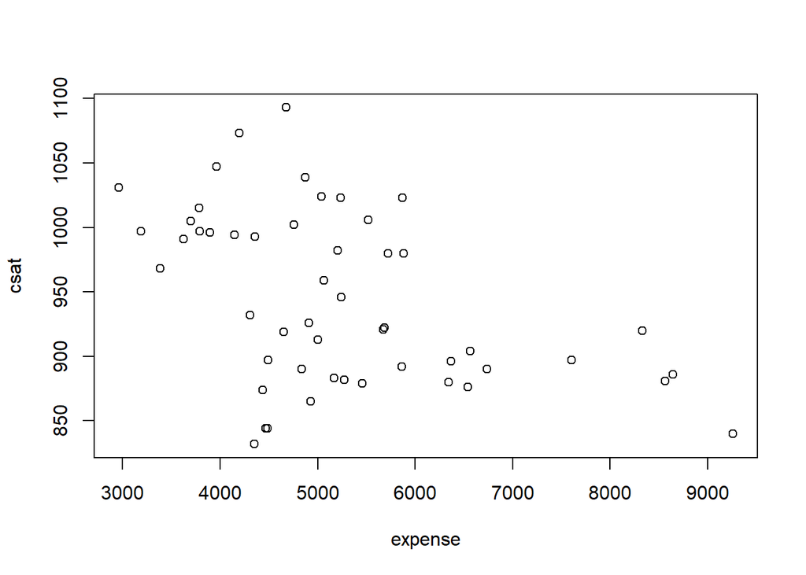

## Fitting the Regression Analysis

Linear regression models can be fit with the `lm()' function For example, we can use`lm’ to predict SAT scores based on per-pupal expenditures. Then the results will be summarized and printed.

```
##
## Call:
## lm(formula = csat ~ expense, data = states.data)
##
## Residuals:
##      Min       1Q   Median       3Q      Max
## -131.811  -38.085    5.607   37.852  136.495
##
## Coefficients:
##               Estimate Std. Error t value Pr(>|t|)
## (Intercept)  1.061e+03  3.270e+01   32.44  < 2e-16 ***
## expense     -2.228e-02  6.037e-03   -3.69 0.000563 ***
## ---
## Signif. codes:  0 '***' 0.001 '**' 0.01 '*' 0.05 '.' 0.1 ' ' 1
##
## Residual standard error: 59.81 on 49 degrees of freedom
## Multiple R-squared:  0.2174, Adjusted R-squared:  0.2015
## F-statistic: 13.61 on 1 and 49 DF,  p-value: 0.0005631
```

## Why is the association between expense and SAT scores negative?

Many people find it surprising that the per-capita expenditure on students is negatively related to SAT scores. The beauty of multiple regression is that we can try to pull these apart.  
What would the association between expense and SAT scores be if there were no difference among the states in the percentage of students taking the SAT?

```
##
## Call:
## lm(formula = csat ~ expense + percent, data = states.data)
##
## Residuals:
##     Min      1Q  Median      3Q     Max
## -62.921 -24.318   1.741  15.502  75.623
##
## Coefficients:
##               Estimate Std. Error t value Pr(>|t|)
## (Intercept) 989.807403  18.395770  53.806  < 2e-16 ***
## expense       0.008604   0.004204   2.046   0.0462 *
## percent      -2.537700   0.224912 -11.283 4.21e-15 ***
## ---
## Signif. codes:  0 '***' 0.001 '**' 0.01 '*' 0.05 '.' 0.1 ' ' 1
##
## Residual standard error: 31.62 on 48 degrees of freedom
## Multiple R-squared:  0.7857, Adjusted R-squared:  0.7768
## F-statistic: 88.01 on 2 and 48 DF,  p-value: < 2.2e-16
```

## The lm Class and Methods

Now we are going to examine the model by class and use se function methods to get more information about the fit.

```
## [1] "lm"
```

```
##  [1] "coefficients"  "residuals"     "effects"       "rank"
##  [5] "fitted.values" "assign"        "qr"            "df.residual"
##  [9] "xlevels"       "call"          "terms"         "model"
```

```
## [1] "add1.lm"                   "alias.lm"
## [3] "anova.lm"                  "case.names.lm"
## [5] "coerce,oldClass,S3-method" "confint.lm"
## [7] "cooks.distance.lm"         "deviance.lm"
## [9] "dfbeta.lm"
```

```
##                    2.5 %        97.5 %
## (Intercept) 995.01753164 1126.44735626
## expense      -0.03440768   -0.01014361
```

## Linear Regression Assumptions

Ordinary least squares regression relies on several assumptions, including that the residuals are normally distributed and homoscedastic, the errors are independent and the relationships are linear.

Im going to Investigate these assumptions visually by plotting the model.

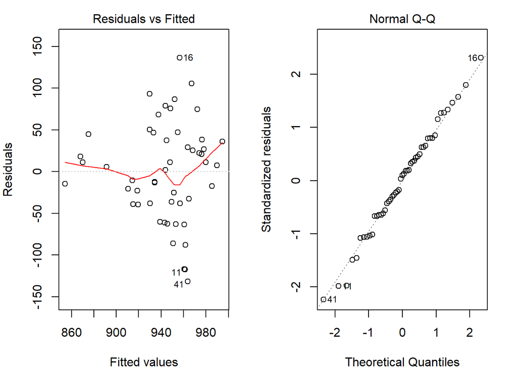

## Comparing Models

Do congressional voting patterns predict SAT scores over and above expense? Im going to Fit two models and compare them and fit another model, adding house and senate as predictors. I will also make a comparision using the anova() function. Then I will plot the two models.

```
## Analysis of Variance Table
##
## Model 1: csat ~ expense
## Model 2: csat ~ expense + house + senate
##   Res.Df    RSS Df Sum of Sq      F  Pr(>F)
## 1     46 169050
## 2     44 149284  2     19766 2.9128 0.06486 .
## ---
## Signif. codes:  0 '***' 0.001 '**' 0.01 '*' 0.05 '.' 0.1 ' ' 1
```

```
##                  Estimate   Std. Error    t value     Pr(>|t|)
## (Intercept) 1082.93438041 38.633812740 28.0307405 1.067795e-29
## expense       -0.01870832  0.009691494 -1.9303852 6.001998e-02
## house         -1.44243754  0.600478382 -2.4021473 2.058666e-02
## senate         0.49817861  0.513561356  0.9700469 3.373256e-01
```

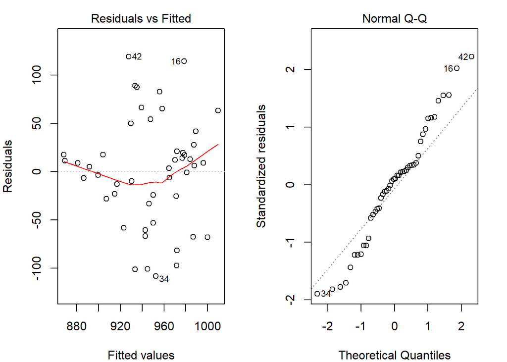

It is ins=teresting to not the differences between the two models and the difference when house and senate predictors are added.

## Exercise: least squares regression

Useing the same data, I will fit a model predicting energy consumed per capita (energy) from the percentage of residents living in metropolitan areas (metro), then fit the model with population density to compare.

```
##
## Call:
## lm(formula = energy ~ metro + percent, data = states.data)
##
## Residuals:
##     Min      1Q  Median      3Q     Max
## -162.83  -67.41  -33.60    4.99  603.45
##
## Coefficients:
##             Estimate Std. Error t value Pr(>|t|)
## (Intercept) 503.0773    61.4240   8.190 1.33e-10 ***
## metro        -1.7215     1.0093  -1.706   0.0947 .
## percent      -1.0920     0.8517  -1.282   0.2061
## ---
## Signif. codes:  0 '***' 0.001 '**' 0.01 '*' 0.05 '.' 0.1 ' ' 1
##
## Residual standard error: 139.2 on 47 degrees of freedom
##   (1 observation deleted due to missingness)
## Multiple R-squared:  0.1453, Adjusted R-squared:  0.1089
## F-statistic: 3.996 on 2 and 47 DF,  p-value: 0.02497
```

[output not shown]

```
##               Estimate Std. Error   t value     Pr(>|t|)
## (Intercept) 449.838200 50.4471770  8.917014 1.367139e-11
## metro        -1.652596  0.7428401 -2.224700 3.104752e-02
```

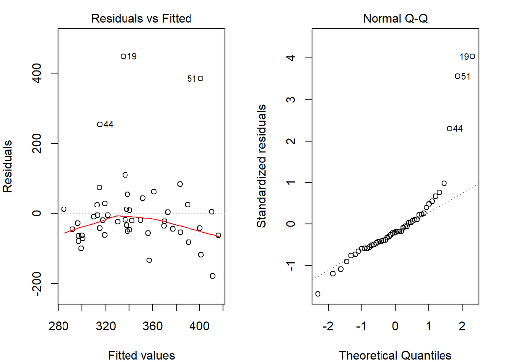

[output not shown]

[output not shown]

```
##                Estimate  Std. Error    t value     Pr(>|t|)
## (Intercept) 420.4446223 54.05903420  7.7775089 7.279704e-10
## metro        -0.8806209  0.91532256 -0.9620881 3.411469e-01
## density      -0.1195820  0.08452717 -1.4147165 1.640343e-01
```

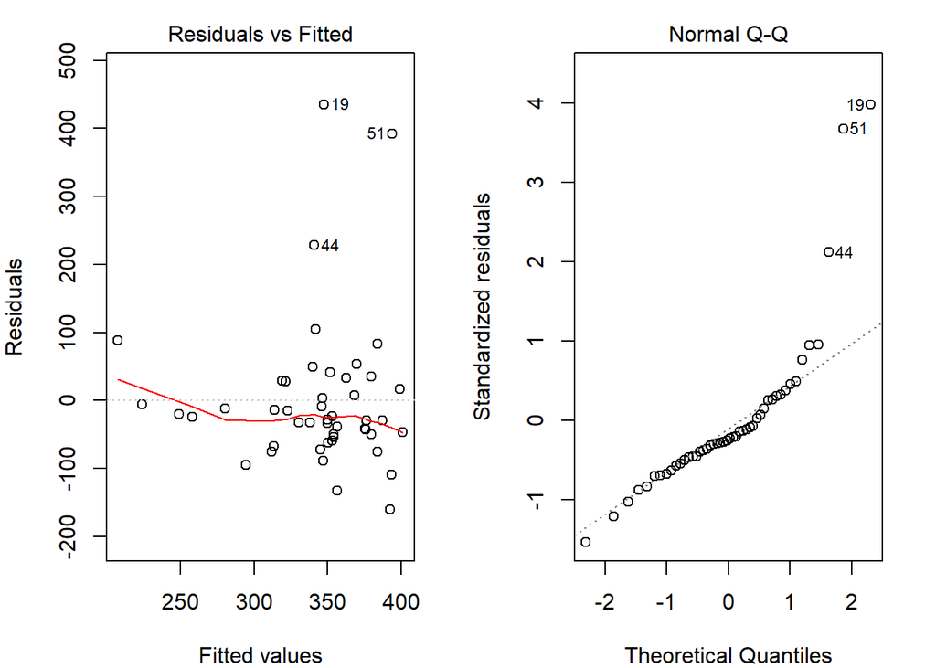

These plots show three interesting outliers.

## Setting factor reference groups and contrasts

```
##         N. East South Midwest
## West          0     0       0
## N. East       1     0       0
## South         0     1       0
## Midwest       0     0       1
```

```
##                        Estimate Std. Error   t value     Pr(>|t|)
## (Intercept)          1010.08333   15.39998 65.589930 4.296307e-47
## C(region, base = 4)1  -63.77564   21.35592 -2.986321 4.514152e-03
## C(region, base = 4)2 -120.52778   23.52385 -5.123641 5.798399e-06
## C(region, base = 4)3  -80.08333   20.37225 -3.931000 2.826007e-04
```

```
##                             Estimate Std. Error     t value     Pr(>|t|)
## (Intercept)               943.986645   7.706155 122.4977451 1.689670e-59
## C(region, contr.helmert)1 -28.376068  11.566423  -2.4533141 1.800383e-02
## C(region, contr.helmert)2   4.022792   5.884552   0.6836191 4.976450e-01
## C(region, contr.helmert)3  22.032229   4.446777   4.9546509 1.023364e-05
```